# [**Pattern Discovery in Data Mining** *Programming Assignment: Frequent Itemset Mining Using Apriori*](https://www.coursera.org/learn/data-patterns)

[**Data Mining** *by University of Illinois at Urbana-Champaign*](https://www.coursera.org/specializations/data-mining)

[®γσ, Eng Lian Hu](http://englianhu.wordpress.com) 白戸則道®

2016-09-22

# Abstract

## Programming Assignment: Frequent Itemset Mining Using Apriori

You have not submitted. You must earn *70/100 points* to pass. Deadline *Pass this assignment by September 4, 11:59 PM PDT*

# 1. Instructions

- Section 1.1 Input
- Section 1.2 Output
- Section 1.3 Important Tips

**Description**

In this programming assignment, you are required to implement the Apriori algorithm and apply it to mine frequent itemsets from a real-life data set.

## 1.1 Input

The provided input file (“categories.txt”) consists of the category lists of 77,185 places in the US. Each line corresponds to the category list of one place, where the list consists of a number of category instances (e.g., hotels, restaurants, etc.) that are separated by semicolons.

An example line is provided below:

Local Services; IT Services & Computer Repair

In the example above, the corresponding place has two category instances: “Local Services” and “IT Services & Computer Repair”.

[`categories.txt`](https://github.com/englianhu/Coursera-Data-Mining/blob/master/4%20Pattern%20Discovery%20in%20Data%20Mining/data/categories.txt)

## 1.2 Output

You need to implement the Apriori algorithm and use it to mine category sets that are frequent in the input data. When implementing the Apriori algorithm, you may use any programming language you like. We only need your result pattern file, not your source code file.

After implementing the Apriori algorithm, please set the relative minimum support to 0.01 and run it on the 77,185 category lists. In other words, you need to extract all the category sets that have an absolute support no smaller than 771.

### Part 1

Please output all the length-1 frequent categories with their absolute supports into a text file named “patterns.txt”. Every line corresponds to exactly one frequent category and should be in the following format:

`support:category`

For example, suppose a category (Fast Food) has an absolute support 3000, then the line corresponding to this frequent category set in “patterns.txt” should be:

`3000:Fast Food`

### Part 2

Please write all the frequent category sets along with their absolute supports into a text file named “patterns.txt”. Every line corresponds to exactly one frequent category set and should be in the following format:

For example, suppose a category set (Fast Food; Restaurants) has an absolute support 2851, then the line corresponding to this frequent category set in “patterns.txt” should be:

`2851:Fast Food;Restaurants`

## 1.3 Important Tips

Make sure that you format each line correctly in the output file. For instance, use a semicolon instead of another character to separate the categories for each frequent category set.

In the result pattern file, the order of the categories does not matter. For example, the following two cases will be considered equivalent by the grader:

Case 1:

`2851:Fast Food;Restaurants`

Case 2:

`2851:Restaurants;Fast Food`

# 2. My submission

- Section 2.1 Frequent Single Item Mining
- Section 2.2 Frequent Itemset Mining using Apriori

**Upload Files and Submit**

To upload a file, click the part below. Then, submit the files. You can submit as many times as you like. You do not need to upload all parts in order to submit.

- Frequent Single Item Mining (*30 points*)
- Frequent Itemset Mining using Apriori (*70 points*)

## 2.1 Frequent Single Item Mining

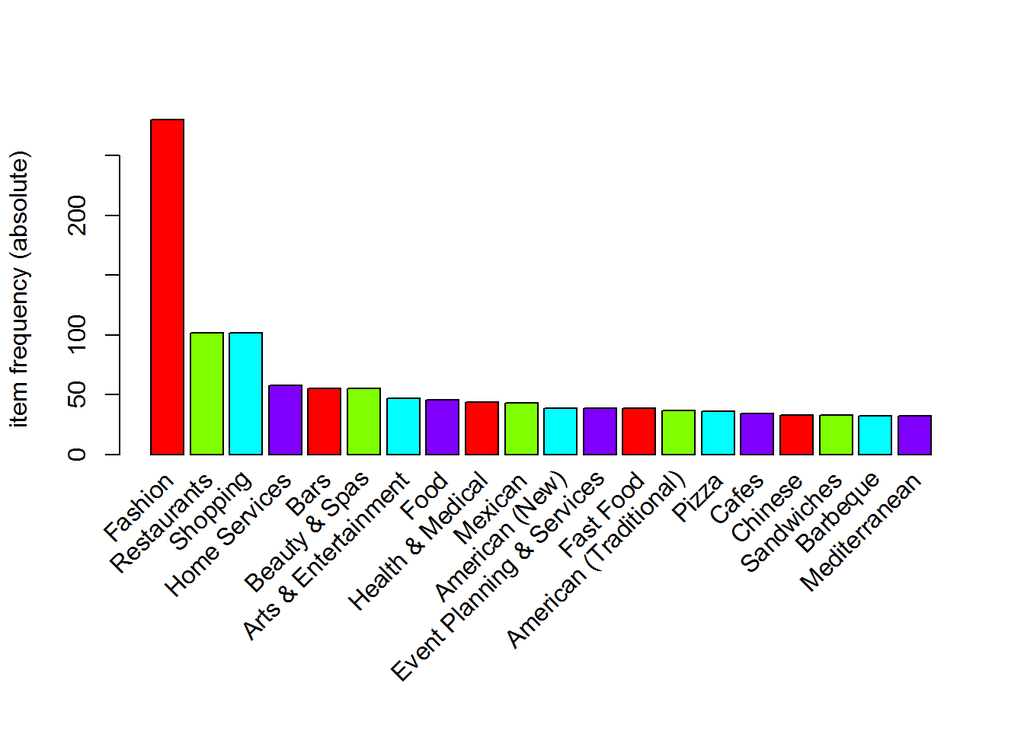

*graph 2.1.1a : explore the top 20 items in the dataset.*

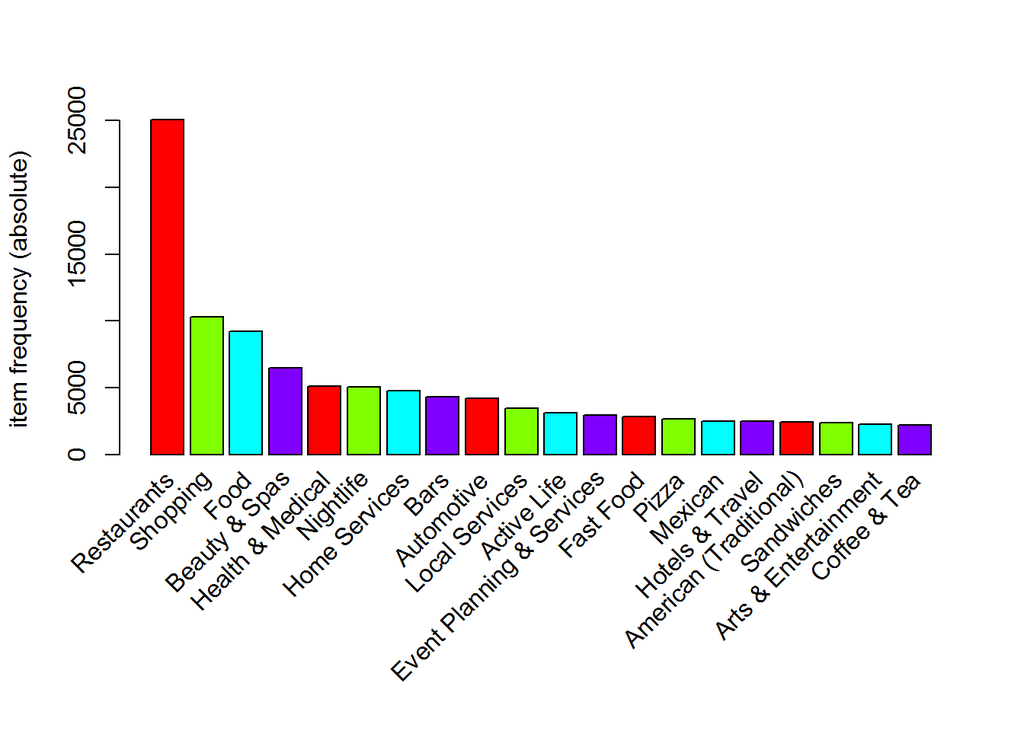

*graph 2.1.1b : explore the top 20 items in the dataset.*

```r
inspect(transDat[1:10]) # view the observations
```

```
##    items                                    transactionID
## 1  {Fashion}                          Accessories
## 2  {Professional Services}            Accountants
## 3  {Active Life,
##     Amateur Sports Teams,
##     American (New),
##     American (Traditional),
##     Amusement Parks,
##     Aquariums,
##     Arcades,
##     Archery,
##     Arts & Entertainment,
##     ATV Rentals/Tours,
##     Automotive,
##     Barre Classes,
##     Bars,
##     Batting Cages,
##     Beaches,
##     Beauty & Spas,
##     Beer, Wine & Spirits,
##     Bike Rentals,
##     Boating,
##     Boot Camps,
##     Bowling,
##     Boxing,
##     Cafes,
##     Car Wash,
##     Challenge Courses,
##     Churches,
##     Climbing,
##     Colleges & Universities,
##     Counseling & Mental Health,
##     Country Clubs,
##     Cycling Classes,
##     Dance Studios,
##     Day Camps,
##     Day Spas,
##     Department Stores,
##     Disc Golf,
##     Diving,
```

[output cut: 92 more lines]

```
##     Bars,
##     Breakfast & Brunch,
##     Nightlife,
##     Party & Event Planning}           Adult Entertainment
## 6  {Halal,
##     Mediterranean,
##     Pakistani,
##     Persian/Iranian,
##     Restaurants}                      Afghan
## 7  {Caribbean,
##     Moroccan,
##     Southern}                         African
## 8  {Bars}                             Airport Lounges
## 9  {Limos}                            Airport Shuttles
## 10 {Doctors}                          Allergists
```

```r
length(transDat) # get number of observations
```

```
## [1] 950
```

```r
size(transDat[1:10]) # number of items in each observation
```

```
##  [1]   1   1 118  10   5   5   3   1   1   1
```

```r
## Endless proceed 3 hours due to length of list, here I omit LIST() and only process inspect().
#'@ LIST(transDat) # convert 'transactions' to a list, note the LIST in CAPS
```

```r
inspect(transDat2[1:100]) # view the observations
```

```
##     items
## 1   {American (Traditional),
##      Breakfast & Brunch,
##      Restaurants}
## 2   {Restaurants,
##      Sandwiches}
## 3   {IT Services & Computer Repair,
##      Local Services}
## 4   {Italian,
##      Restaurants}
## 5   {Coffee & Tea,
##      Food}
## 6   {Fast Food,
##      Restaurants}
## 7   {Home Services,
##      Mortgage Brokers,
##      Real Estate}
## 8   {Brasseries,
##      Restaurants}
## 9   {American (New),
##      Bars,
##      Chicken Wings,
##      Nightlife,
##      Restaurants,
##      Sports Bars}
## 10  {Auto Detailing,
##      Automotive,
##      Wheel & Rim Repair,
##      Windshield Installation & Repair}
## 11  {Auto Parts & Supplies,
##      Automotive}
## 12  {CSA,
##      Farmers Market,
##      Food,
##      Grocery}
## 13  {CPR Classes,
##      Education,
##      First Aid Classes,
##      Specialty Schools}
## 14  {Event Planning & Services,
```

[output cut: 232 more lines]

```
## 95  {Auto Repair,
##      Automotive,
##      Tires}
## 96  {Restaurants,
##      Thai}
## 97  {Mexican,
##      Restaurants}
## 98  {Active Life,
##      Fitness & Instruction,
##      Yoga}
## 99  {Doctors,
##      Health & Medical,
##      Medical Centers}
## 100 {Mexican,
##      Restaurants}
```

```r
length(transDat2) # get number of observations
```

```
## [1] 77185
```

```r
size(transDat2[1:100]) # number of items in each observation
```

```
##   [1] 3 2 2 2 2 2 3 2 6 4 2 4 4 2 4 3 2 2 3 2 2 2 2 3 4 2 4 4 6 2 2 2 2 4 2
##  [36] 5 2 3 4 3 4 3 2 4 5 2 5 2 4 3 4 2 2 3 2 2 3 2 2 2 2 3 2 2 3 2 2 2 4 4
##  [71] 5 1 3 2 2 2 6 2 3 5 2 5 5 3 4 2 2 2 3 2 3 2 3 2 3 2 2 3 3 2
```

```r
## Endless proceed 3 hours due to length of list, here I omit LIST() and only process inspect().
#'@ LIST(transDat) # convert 'transactions' to a list, note the LIST in CAPS
```

```r
head(transDat)
```

```
## transactions in sparse format with
##  6 transactions (rows) and
##  830 items (columns)
```

```r
head(transDat2)
```

```
## transactions in sparse format with
##  6 transactions (rows) and
##  1048 items (columns)
```

```r
frequentItems <- eclat(transDat, parameter = list(supp = 0.07, maxlen = 15)) # calculates support for frequent items
```

```
## Eclat
##
## parameter specification:
##  tidLists support minlen maxlen            target   ext
##     FALSE    0.07      1     15 frequent itemsets FALSE
##
## algorithmic control:
##  sparse sort verbose
##       7   -2    TRUE
##
## Absolute minimum support count: 66
##
## create itemset ...
## set transactions ...[830 item(s), 950 transaction(s)] done [0.00s].
## sorting and recoding items ... [3 item(s)] done [0.00s].
## creating bit matrix ... [3 row(s), 950 column(s)] done [0.00s].
## writing  ... [3 set(s)] done [0.00s].
## Creating S4 object  ... done [0.00s].
```

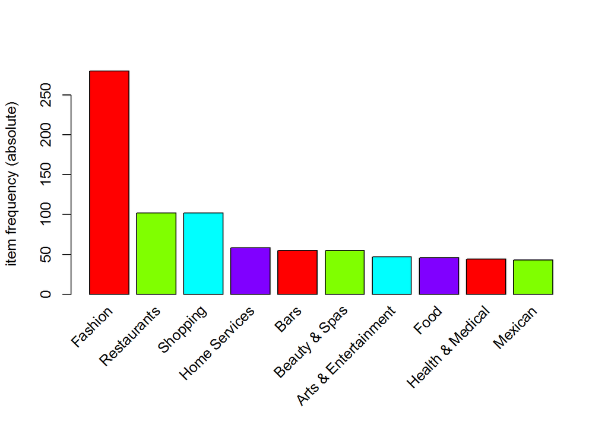

```r
itemFrequencyPlot(transDat, topN = 10, type = 'absolute', col = rainbow(4)) # plot frequent items
```

*graph 2.1.2a : top 10 items in dataset.*

```r
frequentItems <- eclat(transDat2, parameter = list(supp = 0.07, maxlen = 15)) # calculates support for frequent items
```

```
## Eclat
##
## parameter specification:
##  tidLists support minlen maxlen            target   ext
##     FALSE    0.07      1     15 frequent itemsets FALSE
##
## algorithmic control:
##  sparse sort verbose
##       7   -2    TRUE
##
## Absolute minimum support count: 5402
##
## create itemset ...
## set transactions ...[1048 item(s), 77185 transaction(s)] done [0.03s].
## sorting and recoding items ... [4 item(s)] done [0.00s].
## creating bit matrix ... [4 row(s), 77185 column(s)] done [0.00s].
## writing  ... [4 set(s)] done [0.00s].
## Creating S4 object  ... done [0.00s].
```

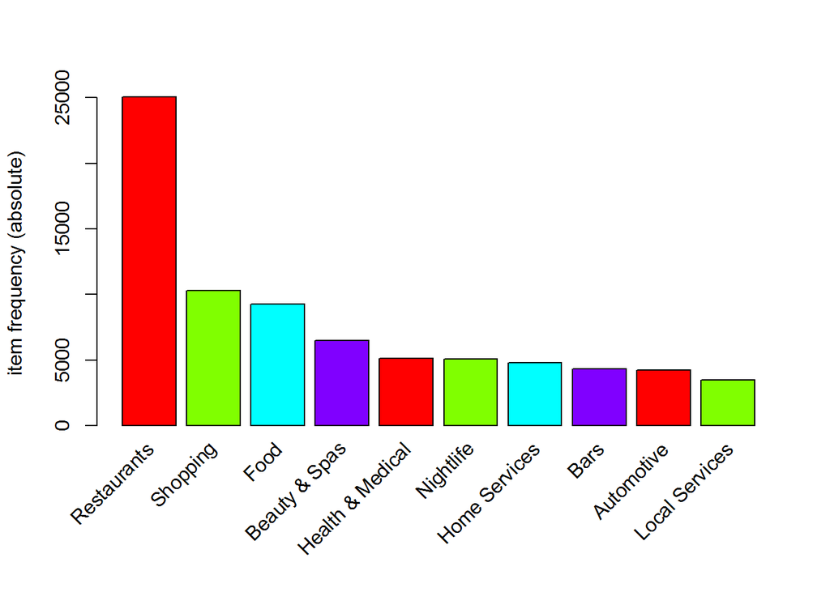

```r
itemFrequencyPlot(transDat2, topN = 10, type = 'absolute', col = rainbow(4)) # plot frequent items
```

*graph 2.1.2b : top 10 items in dataset.*

## 2.2 Frequent Itemset Mining using Apriori

```r
# Get the rules
rules <- apriori(transDat, parameter = list(supp = 0.01, conf = 0.5))
```

```
## Apriori
##
## Parameter specification:
##  confidence minval smax arem  aval originalSupport support minlen maxlen
##         0.5    0.1    1 none FALSE            TRUE    0.01      1     10
##  target   ext
##   rules FALSE
##
## Algorithmic control:
##  filter tree heap memopt load sort verbose
##     0.1 TRUE TRUE  FALSE TRUE    2    TRUE
##
## Absolute minimum support count: 9
##
## set item appearances ...[0 item(s)] done [0.00s].
## set transactions ...[830 item(s), 950 transaction(s)] done [0.00s].
## sorting and recoding items ... [75 item(s)] done [0.00s].
## creating transaction tree ... done [0.00s].
## checking subsets of size 1 2 3 4 5 6 done [0.00s].
## writing ... [2236 rule(s)] done [0.00s].
## creating S4 object  ... done [0.00s].
```

```r
# Show the top 5 rules, but only 2 digits
options(digits=2)
inspect(sort(subset(rules[1:5], subset = lift > 6), by = 'confidence'))
```

```
##   lhs                rhs           support confidence lift
## 4 {Salad}         => {Restaurants} 0.011   1.00        9.3
## 1 {Buffets}       => {Restaurants} 0.013   0.92        8.6
## 3 {Chicken Wings} => {Restaurants} 0.012   0.92        8.5
## 2 {Chicken Wings} => {Barbeque}    0.011   0.83       24.7
## 5 {Caribbean}     => {Restaurants} 0.011   0.83        7.8
```

```r
# Get the rules
rules <- apriori(transDat2, parameter = list(supp = 0.01, conf = 0.5))
```

```
## Apriori
##
## Parameter specification:
##  confidence minval smax arem  aval originalSupport support minlen maxlen
##         0.5    0.1    1 none FALSE            TRUE    0.01      1     10
##  target   ext
##   rules FALSE
##
## Algorithmic control:
##  filter tree heap memopt load sort verbose
##     0.1 TRUE TRUE  FALSE TRUE    2    TRUE
##
## Absolute minimum support count: 771
##
## set item appearances ...[0 item(s)] done [0.00s].
## set transactions ...[1048 item(s), 77185 transaction(s)] done [0.02s].
## sorting and recoding items ... [49 item(s)] done [0.00s].
## creating transaction tree ... done [0.04s].
## checking subsets of size 1 2 3 done [0.00s].
## writing ... [57 rule(s)] done [0.00s].
## creating S4 object  ... done [0.01s].
```

```r
# Show the top 5 rules, but only 2 digits
options(digits=2)
inspect(sort(subset(rules[1:5], subset = lift > 6), by = 'confidence'))
```

```
##   lhs                            rhs                 support confidence
## 3 {Ice Cream & Frozen Yogurt} => {Food}              0.013   1.00
## 4 {General Dentistry}         => {Dentists}          0.011   1.00
## 5 {Dentists}                  => {General Dentistry} 0.011   0.69
##   lift
## 3  8.3
## 4 64.6
## 5 64.6
```

# 3. Conclusion

I will also conducting a market basket analysis in [Betting Strategy and Model Validation](https://github.com/scibrokes/betting-strategy-and-model-validation) with regards sportsbook betting.

# 4. Appendices

- Section 4.1 Documenting File Creation
- Section 4.2 Speech and Blooper
- Section 4.3 References

## 4.1 Documenting File Creation

It’s useful to record some information about how your file was created.

- File creation date: 2016-09-03
- File latest updated date: 2016-09-22
- R version 3.3.1 (2016-06-21)
- R version (short form): 3.3.1
- [**rmarkdown** package](https://github.com/rstudio/rmarkdown) version: 1.0.9013
- [**tufte** package](https://github.com/rstudio/tufte) version: 0.2.2
- File version: 1.0.0
- Author Profile: [®γσ, Eng Lian Hu](https://beta.rstudioconnect.com/englianhu/ryo-eng/)
- GitHub: [Source Code](https://github.com/englianhu/Coursera-Data-Mining/blob/master/4%20Pattern%20Discovery%20in%20Data%20Mining/Programming%20Assignment%20-%20Frequent%20Itemset%20Mining%20Using%20Apriori.Rmd)
- Additional session information

[1] “2016-09-22 01:39:40 JST”

| Category | session_info |
| --- | --- |
| version | R version 3.3.1 (2016-06-21) |
| system | x86_64, mingw32 |
| ui | RTerm |
| language | en |
| collate | English_United States.1252 |
| tz | Asia/Tokyo |
| date | 2016-09-22 |

| Category | Sys.info |
| --- | --- |
| sysname | Windows |
| release | 10 x64 |
| version | build 14393 |
| nodename | RSTUDIO-SCIBROK |
| machine | x86-64 |
| login | scibr |
| user | scibr |
| effective_user | scibr |

## 4.2 Speech and Blooper

All `plot()` funtion for `arules` in rmarkdown unable work but run chunk-by-chunk is working fine.

## 4.3 References

1. [A biased comparsion of JSON packages in R](https://rstudio-pubs-static.s3.amazonaws.com/31702_9c22e3d1a0c44968a4a1f9656f1800ab.html)
2. [**Introduction to arules – A computational environment for mining association rules and frequent item sets** *by Michael Hahsler, Bettina Grun, Kurt Hornik, Christian Buchta (2015)*](https://cran.r-project.org/web/packages/arules/vignettes/arules.pdf)
3. [**Association Rules and Market Basket Analysis with R** *by David Smith (2015)*](http://blog.revolutionanalytics.com/2015/04/association-rules-and-market-basket-analysis-with-r.html)
4. [**Market Basket Analysis with R** *by Salem (2014)*](http://www.salemmarafi.com/code/market-basket-analysis-with-r/)
5. [**ASSOCIATION MINING: WHAT PRODUCTS TO RECOMMEND TO YOUR CUSTOMERS BASED ON HISTORIC BUYING PATTERNS?** *by RSTATISTICS.NET*](http://rstatistics.net/association-mining-with-r/)
6. [**RPubs - LastFM Prediction Using Market Basket Analysis** *by Ranjit Mishra (2015)*](https://rpubs.com/ranjitmishra/124373)